# Report: Predict Bike Sharing Demand with AutoGluon Solution

## Initial Training

### What did you realize when you tried to submit your predictions? What changes were needed to the output of the predictor to submit your results?

I realized that I can't export anything to Kaggle and that I needed to !pip install kaggle first. No changes to the output of the predictor were needed, because I followed the instructions and wrote the code that replaces the negative values with zeroes beforehand.

### What was the top ranked model that performed?

WeightedEnsemble_L3

## Exploratory data analysis and feature creation

### What did the exploratory analysis find and how did you add additional features?

I used datetime splitted to add additional features: month, day and hour.

### How much better did your model preform after adding additional features and why do you think that is?

Splitting date into additional features like month, day and hour actually helped a lot, and instantly made the model perform three times (!) as good. This highlights just how imprortant the right kinds of data are for good results, and how useless can be unwrangled data.

## Hyper parameter tuning

### How much better did your model preform after trying different hyper parameters?

It actually performed better than the initial model (1.79), but much worse (1.34) than the additional_feature model (0.69). I lated found out that it was due to the fact that I made a pause before tuning hyperparameters and shut down SageMaker. When resuming my work later, I did not run every cell again (to save time and costs), and so I was training the tuned models on the initial train set, without the added features.

!! When I finally reran the whole notebook, the hpo models started to perform much better, on the level of new_feature models (as expected). -> Specifying the number of leaves did not help much and performance slightly deteriorated. -> Specifying the number of boost rounds -> Specifying the learning rate

### If you were given more time with this dataset, where do you think you would spend more time?

I will denifitely spend more time not tuning different models, but studying the data and maybe trying to split them even further to produce additional features. HPO influenced my model performance to a lesser extent than better data. On the second place, I would explore different hyperparameters and try to understand, which of them could produce greater effects.

### Create a table with the models you ran, the hyperparameters modified, and the kaggle score.

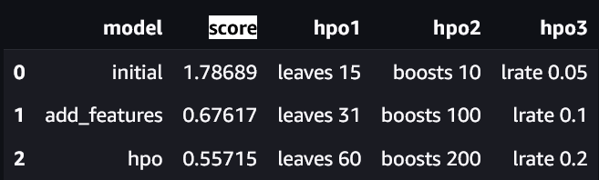

### Create a line plot showing the top model score for the three (or more) training runs during the project.

The score significantly improved, then fell a bit down, but stayed high.

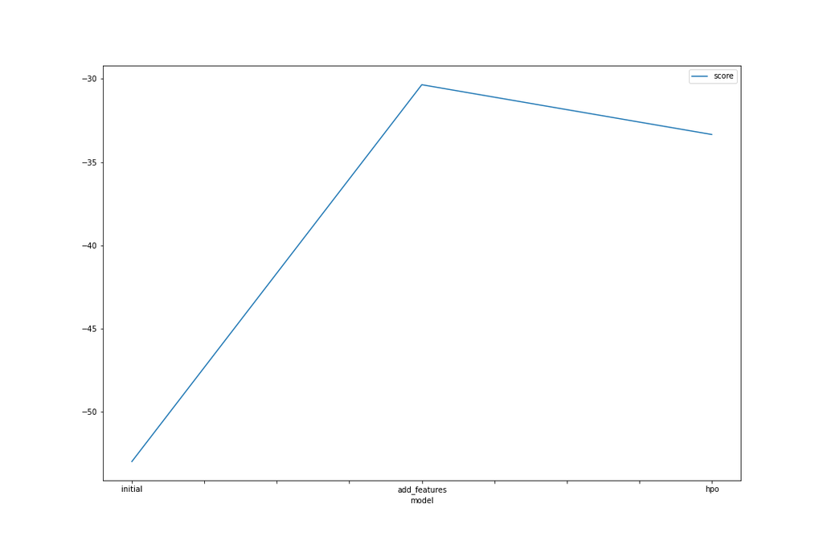

### Create a line plot showing the top kaggle score for the three (or more) prediction submissions during the project.

I managed to improve my model on every step!

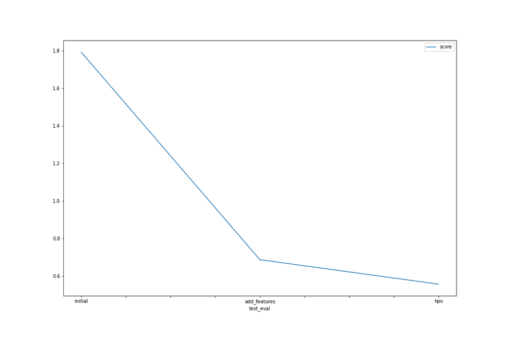

## Summary

To sum up, there are the ways how I managed to improved my model to eventually get a higher score (raising to 0.56 from 1.79 is a huge progress):

- running many models to choose the best one
- creating additional features
- using the best-performing model type to fine-tune it
- trying various hyperparameters
- varying the learning rate